**Dynamical Systems:**  
**Complex Number and Harmonic Motion**

Table of Contents

# 1. Complex Numbers

A **complex number** is an expression of the form:

$$ z = a + bi $$

where $a, b \in \mathbb{R}$, and $i$ is the imaginary unit satisfying $i^2 = -1$.

Complex numbers can be represented both **algebraically** and **geometrically** (as vectors in the complex plane).

For example:

$$ z_1 = a_1 + b_1i, \quad \vec{z}_1 = \begin{bmatrix} a_1 \\ b_1 \end{bmatrix} $$

$$ z_2 = a_2 + b_2i, \quad \vec{z}_2 = \begin{bmatrix} a_2 \\ b_2 \end{bmatrix} $$

## 1.1. Operations with Complex Numbers

**Addition**

The sum of two complex numbers $z_1$ and $z_2$ is obtained by adding their real and imaginary parts:

$$ \begin{aligned} z &= z_1 + z_2 \\ &= (a_1 + a_2) + (b_1 + b_2)i \end{aligned} $$

In vector form, this corresponds to vector addition:

$$ \begin{aligned} \vec{z} &= \vec{z}_1 + \vec{z}_2 \\ &= \begin{bmatrix} a_1 \\ b_1 \end{bmatrix} + \begin{bmatrix} a_2 \\ b_2 \end{bmatrix} \\ &= \begin{bmatrix} a_1 + a_2 \\ b_1 + b_2 \end{bmatrix} \end{aligned} $$

This interpretation is fundamental for understanding complex numbers geometrically in the complex plane, where they correspond to vectors from the origin to the point $(a,b)$.

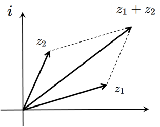

**Multiplication and Division of Complex Numbers**

Complex numbers can be conveniently expressed in polar (or exponential) form:

$$ z_1 = r_1 e^{i \theta_1}, \quad z_2 = r_2 e^{i \theta_2} $$

where:

- $r_i = |z_i|$ is the **magnitude** (modulus) of $z_i$
- $\theta_i = \arg(z_i)$ is the **argument** (phase angle) of $z_i$

Using this form, we can express multiplication and division as follows:

$$ \begin{cases} z_1 \cdot z_2 = r_1 r_2 e^{i(\theta_1 + \theta_2)} \\\\ \dfrac{z_1}{z_2} = \dfrac{r_1}{r_2} e^{i(\theta_1 - \theta_2)} \end{cases} $$

This shows that:

- When multiplying, magnitudes multiply and angles add.
- When dividing, magnitudes divide and angles subtract.

## 1.2. Euler's Formula

A cornerstone of complex analysis is Euler's formula, which links the exponential and trigonometric representations of complex numbers:

$$ e^{i\theta} = \cos\theta + i \sin\theta $$

**Complex Number in Polar (Exponential) Form**

Combining magnitude and angle:

$$ \begin{aligned} z &= r \cos\theta + i r \sin\theta \\ &= r (\cos\theta + i \sin\theta) \\ &= r e^{i\theta} \end{aligned} $$

where:

- $r$ is the magnitude (length) of the complex number:

$$ r = |z| = \sqrt{a^2 + b^2} $$

- $\theta$ is the phase (angle):

$$ \theta = \arg(z) = \tan^{-1}\left(\dfrac{b}{a}\right) $$

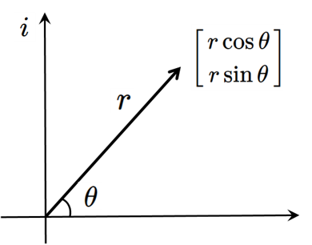

### 1.2.1. Geometrical Meaning of $e^{i\theta}$

The complex exponential $e^{i\theta}$ has a rich geometrical interpretation in the complex plane:

- **$e^{i\theta}$** represents a point on the **unit circle** in the complex plane, located at an angle $\theta$ measured from the positive real axis (counterclockwise).

Mathematically:

$$ e^{i\theta} = \cos\theta + i\sin\theta $$

Geometrically, this corresponds to the point:

$$ (\cos\theta, \sin\theta) $$

which lies on the unit circle.

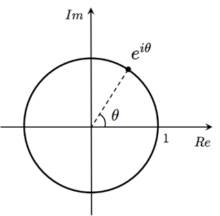

### 1.2.2. Time-Dependent Angle: $\theta = \omega t$

If we let the angle $\theta$ evolve over time as $\theta = \omega t$, where $\omega$ is the angular velocity, we obtain:

$$ e^{i\omega t} $$

This describes a point rotating counterclockwise on the unit circle with angular velocity $\omega$. At any time $t$, the angle from the positive real axis is $\omega t$.

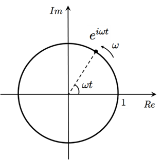

**Physical Meaning of $e^{-i\omega t}$**

The complex exponential:

$$ e^{-i\omega t} $$

represents a point rotating clockwise on the unit circle with the same angular velocity $\omega$. Specifically:

- The angle from the positive real axis at time $t$ is $-\omega t$.
- This is the mirror image of $e^{i\omega t}$ with respect to the real axis.

In physical terms, $e^{-i\omega t}$ can model:

- Clockwise rotation in mechanical or electrical systems
- Complex conjugate behavior in signal processing (e.g., representing negative frequencies)
- Time reversal symmetry in dynamical systems

**Summary**

- $e^{i\theta}$: counterclockwise rotation by angle $\theta$
- $e^{i\omega t}$: counterclockwise rotation with angular velocity $\omega$
- $e^{-i\omega t}$: clockwise rotation with angular velocity $\omega$

## 1.3. Sinusoidal Functions from Circular Motions

Complex exponentials such as $e^{i\omega t}$ represent circular motion in the complex plane, where $\omega$ is the angular velocity and $t$ is time. This motion can be decomposed into projections onto the real and imaginary axes, which correspond to cosine and sine functions, respectively.

**Geometric Interpretation**

- The complex exponential $e^{i\omega t}$ traces a counterclockwise circle with radius 1 as $t$ increases.
- The real part corresponds to the projection onto the real ($\Re$) axis, giving a cosine wave.
- The imaginary part corresponds to the projection onto the imaginary ($\Im$) axis, giving a sine wave.

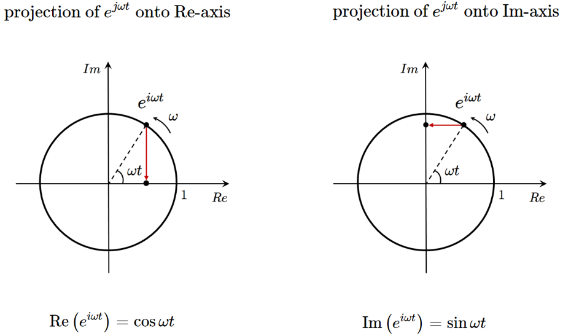

**Projections**

- Real Part (Cosine):

$$ \Re(e^{i\omega t}) = \cos \omega t $$

- Imaginary Part (Sine):

$$ \Im(e^{i\omega t}) = \sin \omega t $$

These projections are visualized in the figures, showing how the point $e^{i\omega t}$ on the unit circle casts shadows (projections) onto the $\Re$ and $\Im$ axes.

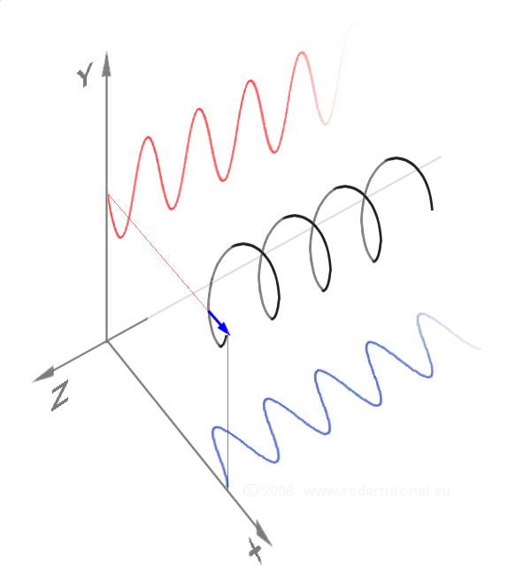

**Euler’s Formula and Trigonometric Identities**

Euler’s formula:

$$ e^{i\omega t} = \cos \omega t + i \sin \omega t $$

Using this, we can express cosine as:

$$ \cos \omega t = \frac{e^{i\omega t} + e^{-i\omega t}}{2} $$

Similarly, sine can be expressed as:

$$ \sin \omega t = \frac{e^{i\omega t} - e^{-i\omega t}}{2i} $$

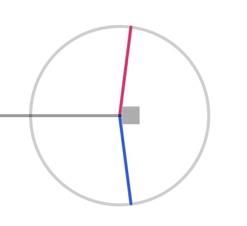

**Physical Interpretation**

- The real projection represents the cosine component of the circular motion, capturing the horizontal displacement as the point rotates.
- The imaginary projection represents the sine component, capturing the vertical displacement.

Together, these form the basis of sinusoidal signals commonly used in physics, engineering, and signal processing.

## 1.4. Multiplication by $i$

Let’s explore the effect of multiplying a complex number by $i$

$$ \begin{align*} ie^{i\theta} & = {?}\\ \\ z_1 & = i = e^{i \frac{\pi}{2}}\\ \\ z_2 & = e^{i\theta} \\ \\ z_1 \cdot z_2 &= e^{i \left(\frac{\pi}{2} + \theta \right)} \end{align*} $$

Thus, multiplying a complex number by $i$ corresponds to rotating it by $90^{o}$ counterclockwise in the complex plane.

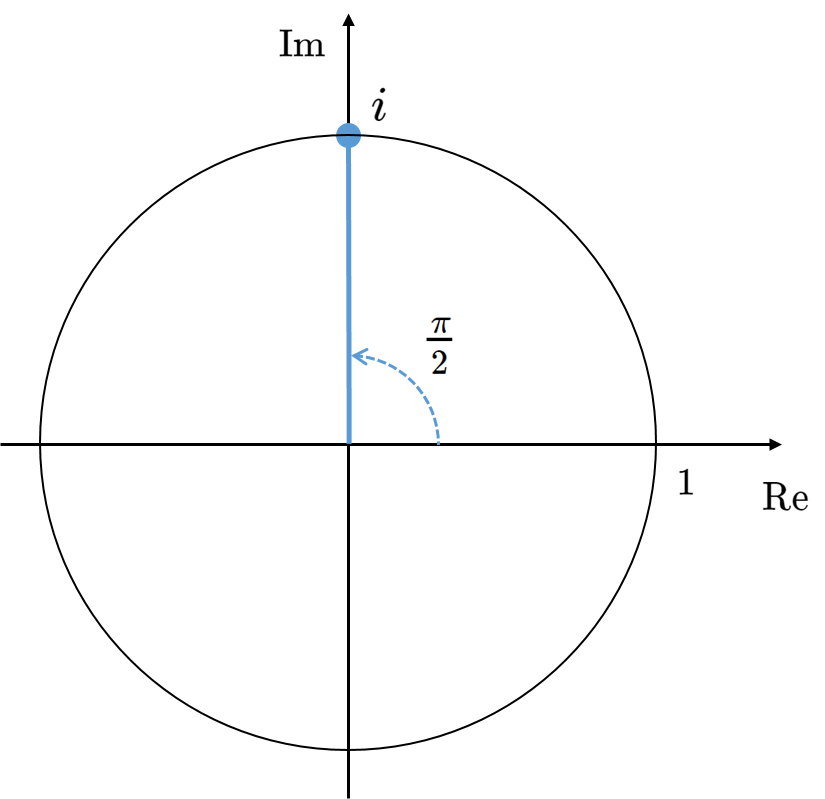

## 1.5. n-th Power of the Complex Exponential

Consider a complex number expressed in exponential form:

$$ \begin{aligned} z &= e^{i\theta} \\[10pt] z^n &= \left(e^{i\theta}\right)^n = e^{in\theta} \end{aligned} $$

This identity follows directly from the rules of exponents for exponentials.

**Example: Solving $z^{12} = 1$**

We are tasked with finding all complex solutions of:

$$ z^{12} = 1 $$

Express 1 in exponential form:

$$ 1 = e^{i2\pi k}, \quad k \in \mathbb{Z} $$

Thus, we set:

$$ z^{12} = e^{i2\pi k} $$

Taking the 12th root on both sides gives:

$$ z = e^{i \frac{2\pi k}{12}} = e^{i \frac{\pi k}{6}}, \quad k = 0, 1, \dots, 11 $$

These are the 12th roots of unity, evenly spaced around the unit circle in the complex plane.

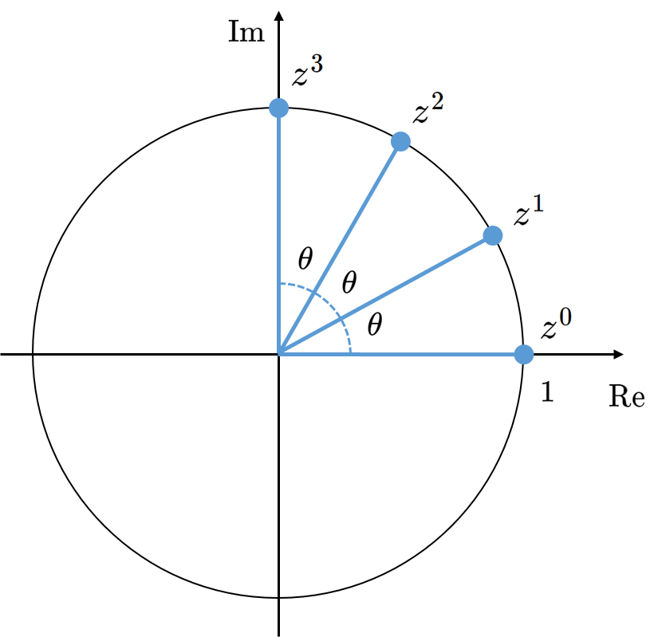

## 1.6. Differential and Integral Operations

Let us consider the meaning of differential and integral operations applied to the complex exponential $e^{j\omega t}$, which will be revisited later in the context of PID controllers.

**Differentiation (Future Behavior)**

Differentiating $e^{j\omega t}$ with respect to time:

$$ \frac{d}{dt} \left( e^{j\omega t} \right) = j \omega e^{j\omega t} = \omega e^{j\frac{\pi}{2}} e^{j\omega t} = \omega e^{j \left( \omega t + \frac{\pi}{2} \right)} $$

This result indicates that differentiation of a complex exponential corresponds to a phase shift of $+\frac{\pi}{2}$ (i.e., $90^\circ$) and scaling by $\omega$.

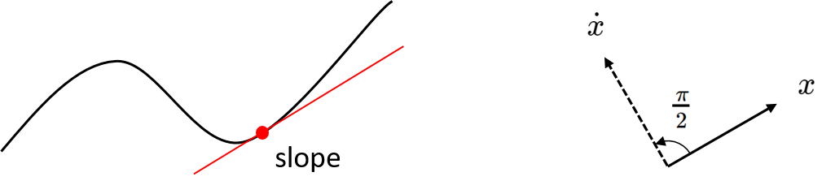

**Integration (Past or Historical Information)**

Integrating $e^{j\omega t}$ with respect to time:

$$ \int e^{j\omega t} \, dt = \frac{1}{j\omega} e^{j\omega t} = \frac{1}{\omega} (-j) e^{j\omega t} = \frac{1}{\omega} e^{j \left( \omega t - \frac{\pi}{2} \right)} $$

Integration thus corresponds to a phase shift of $-\frac{\pi}{2}$ (i.e., $-90^\circ$) and scaling by $\frac{1}{\omega}$.

These operations reflect how differentiation emphasizes the future rate of change, while integration accumulates past information. Both are essential in signal processing and control theory.

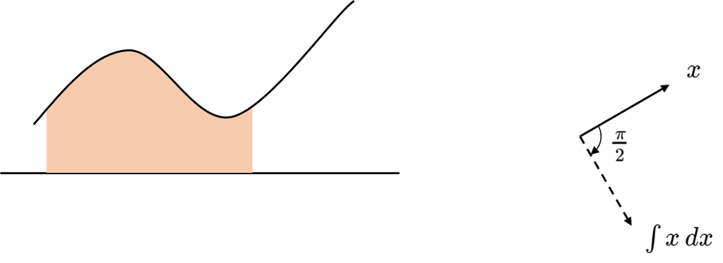

# 2. Circular Motion

A particle rotates on a circle of radius $r$ with an angular velocity $\omega$.

$$ p(t) = r e^{i\omega t} $$

Here, $p(t)$ represents the particle's position vector in the complex plane.

## 2.1. Velocity in Circular Motion

The velocity $v(t)$ is the derivative of position:

$$ v(t) = \frac{d p(t)}{d t} = r \cdot i \omega e^{i\omega t} = i r \omega e^{i\omega t} $$

Magnitude of velocity:

$$ |v(t)| = r \omega $$

Phase angle (relative to the real axis):

$$ \angle v(t) = \omega t + \frac{\pi}{2} $$

This indicates the velocity vector is always perpendicular to the position vector.

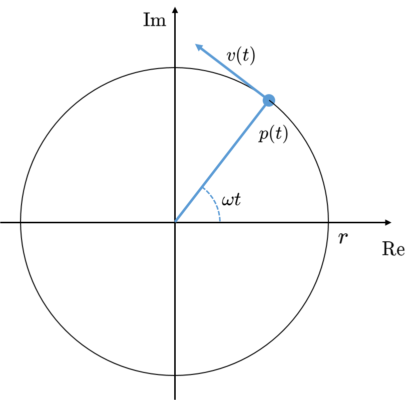

## 2.2. Acceleration in Circular Motion

The acceleration $a(t)$ is the derivative of velocity:

$$ a(t) = \frac{d v(t)}{dt} = r \omega i \cdot i \omega e^{i\omega t} = -r \omega^2 e^{i\omega t} $$

Magnitude of acceleration:

$$ |a(t)| = r \omega^2 $$

Phase angle:

$$ \angle a(t) = \omega t + \pi $$

The acceleration vector is always directed opposite to the position vector, pointing toward the circle's center (centripetal acceleration).

**Key Geometric Insight**

- Position vector rotates with $\omega t$
- Velocity vector leads by $\frac{\pi}{2}$ (perpendicular)
- Acceleration vector leads by $\pi$ (opposite direction)

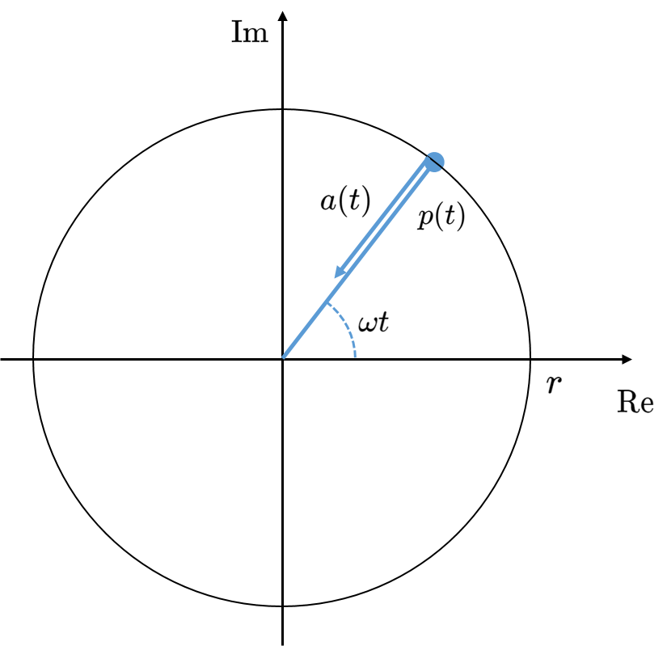

# 3. Harmonic Motion

## 3.1. Spring and Mass System

Consider a mass-spring system where a mass $m$ is attached to a spring of stiffness $k$. The system experiences no damping or external forces.

Type of Motion: Simple harmonic motion (SHM)

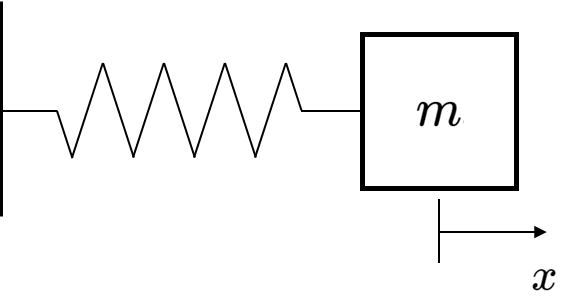

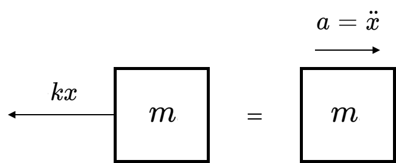

**Equation of Motion**:

$$ \begin{aligned} F &= -kx = m \ddot{x} \\\\ m \ddot{x} + kx &= 0 \\\\ \ddot{x} + \frac{k}{m} x &= 0 \\\\ \ddot{x} + \omega_n^2 x &= 0, \quad \omega_n = \sqrt{\frac{k}{m}} \end{aligned} $$

Characteristics:

- A second-order ordinary differential equation (ODE)
- No external forces; $-kx$ represents the restoring force
- The solution is fully determined by initial conditions:

$$ \begin{cases} x(0) = x_0 \\\\ \dot{x}(0) = v_0 \end{cases} $$

General Solution:

$$ x(t) = R \cos(\omega_n t + \phi) $$

where $R$ (amplitude) and $\phi$ (phase) are determined by the initial conditions.

## 3.2. Circular Motion Interpretation

Simple harmonic motion can be interpreted as the projection of a particle moving in uniform circular motion in the complex plane.

Position in Complex Plane:

$$ z(t) = R e^{j(\omega_n t + \phi)} $$

Derivatives:

$$ \begin{aligned} \dot{z}(t) &= j \omega_n R e^{j(\omega_n t + \phi)} = j \omega_n z(t) \\\\ \ddot{z}(t) &= -\omega_n^2 R e^{j(\omega_n t + \phi)} = -\omega_n^2 z(t) \end{aligned} $$

Thus,

$$ \ddot{z}(t) + \omega_n^2 z(t) = 0 $$

The real part of $z(t)$ gives the displacement:

$$ x(t) = \Re[z(t)] = R \cos(\omega_n t + \phi) $$

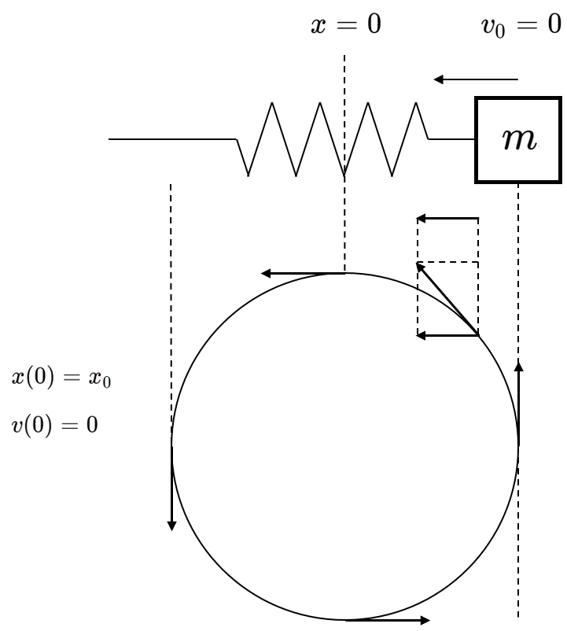

## 3.3. Determining $R$ and $\phi$

Use the initial conditions $x(0)=x_0$ and $\dot{x}(0)=v_0$:

$$ \begin{aligned} x(0) &= R \cos\phi = x_0 \\\\ \dot{x}(0) &= -R \omega_n \sin\phi = v_0 \end{aligned} $$

Solve for $R$ and $\phi$:

$$ \begin{aligned} R &= \sqrt{x_0^2 + \left(\frac{v_0}{\omega_n}\right)^2} \\\\ \phi &= \tan^{-1}\left(-\frac{v_0}{\omega_n x_0}\right) \end{aligned} $$

These uniquely determine the amplitude and phase of the motion based on the initial conditions.

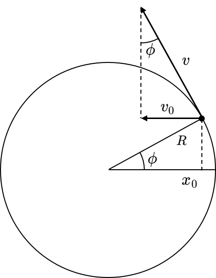

# 4. Pendulum

## 4.1. Equations of Motion

Consider a simple pendulum of length $l$ and mass $m$. Let $\theta$ denote the angular displacement from the vertical.

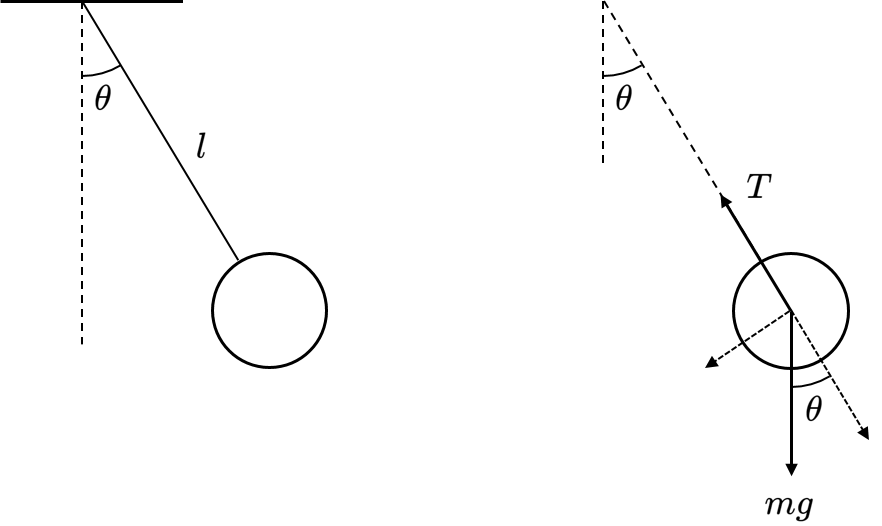

Applying Newton's second law:

$$ \begin{aligned} -T + mg\cos \theta &= -ml\omega^2 \quad \text{(radial)} \\\\ -mg\sin \theta &= m a_t = m l \ddot{\theta} \quad \text{(tangential)} \end{aligned} $$

Thus, the equation of motion for the angular displacement becomes:

$$ m l \ddot{\theta} + mg \sin \theta = 0 $$

which simplifies to:

$$ \ddot{\theta} + \frac{g}{l} \sin \theta = 0 $$

This is a nonlinear second-order ODE.

## 4.2. Linear Approximation

For small angles ($\theta \approx 0$), we can approximate:

$$ \sin \theta \approx \theta $$

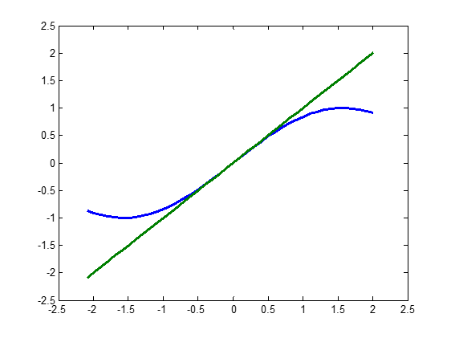

Thus, the equation becomes linear:

$$ \ddot{\theta} + \frac{g}{l} \theta = 0 $$

which represents simple harmonic motion (SHM) with natural frequency:

$$ \omega_n^2 = \frac{g}{l}, \quad \omega_n = \sqrt{\frac{g}{l}} $$

**Observation:**

The period of the pendulum is independent of mass (non-intuitive result):

$$ T = \frac{2\pi}{\omega_n} = 2\pi \sqrt{\frac{l}{g}} $$

```matlab
from IPython.display import YouTubeVideo
YouTubeVideo('YlSC2DfphaY', width = "560", height = "315")
```

[video not shown]

# 5. Simulation of Free Vibration

Consider the complex representation of a free vibration signal:

$$ z(t) = e^{j \omega t} = \cos(\omega t) + j \sin(\omega t) $$

- $\omega$: angular velocity (radians per second)
- $f$: frequency (revolutions per second or hertz, Hz)

The relationship between $\omega$ and $f$ is:

$$ \omega = 2\pi f $$

For one revolution per second ($f=1$ Hz):

$$ \begin{aligned} \omega &= 2\pi \text{ rad/s} \\\\ f &= 1 \text{ Hz} \end{aligned} $$

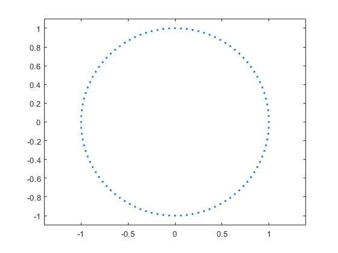

```matlab
t = 0:0.01:1;
f = 1;
w = 2*pi*f;

z = exp(1j*w*t);
plot(real(z),imag(z),'.'), axis equal, ylim([-1.1 1.1])
```

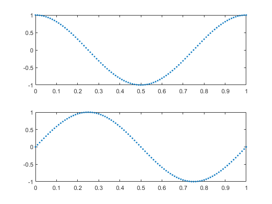

```matlab
subplot(2,1,1), plot(t,real(z),'.')
subplot(2,1,2), plot(t,imag(z),'.')
```

# 6. Damped Free Vibrarion

Real systems exhibit damping, making damped free vibration more realistic than the undamped case.

## 6.1. Mathematical Model and Experiment Insight

Observation: In experiments, a free vibration signal exhibits **exponentially decaying amplitude** while oscillating.

```matlab
from IPython.display import YouTubeVideo
YouTubeVideo('vDulP6vTa9g', width = "560", height = "315")
```

[video not shown]

We model this with:

$$ z(t) = e^{-\gamma t} e^{j \omega t} = e^{-(\gamma + j\omega) t} $$

where:

- $\gamma$: exponential decay rate
- $\omega$: oscillation frequency

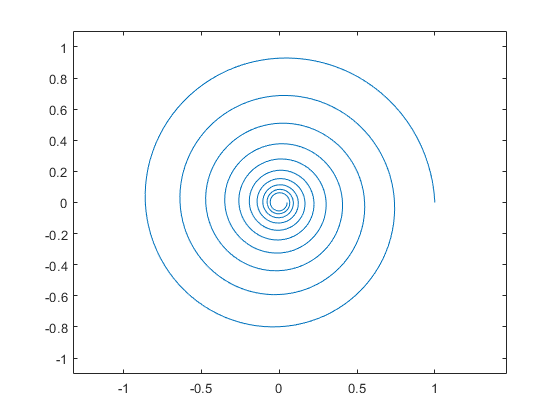

```matlab
r = 0.3;

f = 1;
w = 2*pi*f;

t = 0:0.01:10;
z = exp(-1*r*t).*exp(1j*w*t);

plot(real(z),imag(z)), axis equal, ylim([-1.1,1.1])
```

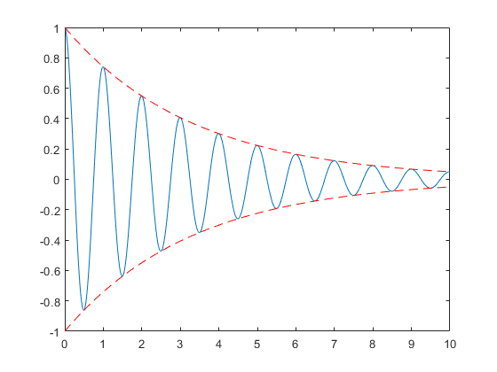

```matlab
plot(t,real(z),t,exp(-1*r*t),'r--',t,-exp(-1*r*t),'r--')
```

Derivatives:

$$ \begin{align*} \dot{z}(t) &= -(\gamma + j\omega) e^{-(\gamma + j\omega) t} \\\\ \ddot{z}(t) &= (\gamma + j\omega)^2 e^{-(\gamma + j\omega) t} \\\\ &= (\gamma^2 - \omega^2 + j 2\gamma \omega) e^{-(\gamma + j\omega) t} \end{align*} $$

Verification of the Differential Equation:

$$ \frac{d^2z}{dt^2} + 2\gamma \frac{dz}{dt} + (\gamma^2 + \omega^2) z(t) $$

Substituting the derivatives:

$$ = (\gamma^2 - \omega^2 + j2\gamma \omega) e^{-(\gamma + j\omega) t} - 2\gamma(\gamma + j\omega)e^{-(\gamma + j\omega)t} + (\gamma^2 + \omega^2) e^{-(\gamma + j\omega) t} = 0 $$

Thus, $z(t)$ satisfies:

$$ \ddot{z}(t) + 2\gamma \dot{z}(t) + (\gamma^2 + \omega^2) z(t) = 0 $$

**General Solution:**

The solution is a linear combination of two exponentials:

$$ z(t) = e^{-\gamma t}(A e^{j\omega t} + B e^{-j\omega t}) $$

where $A,B$ are determined by initial conditions.

## 6.2. Mass-Spring-Damper System

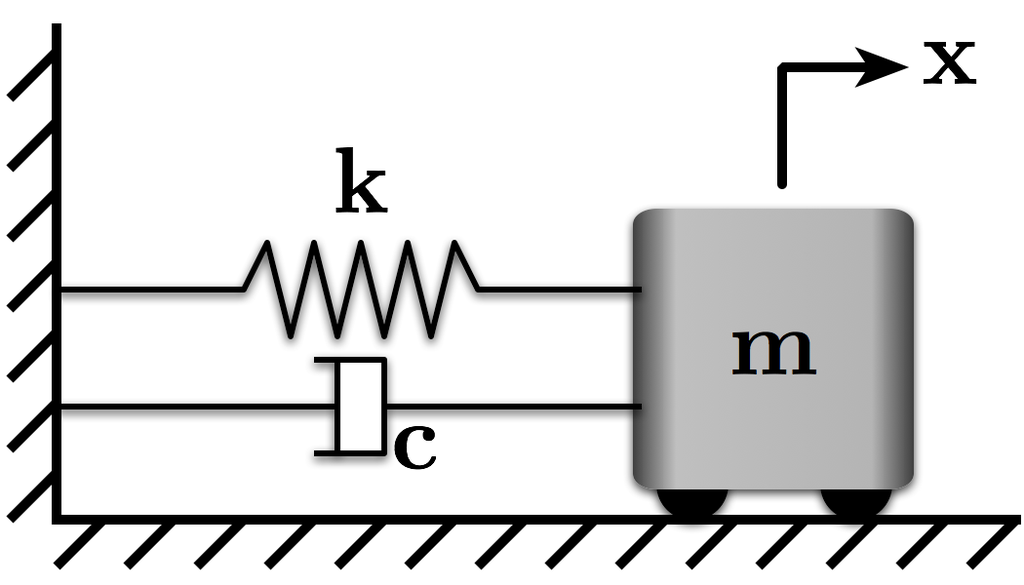

The physical model is:

$$ m\ddot{x}(t) + c\dot{x}(t) + kx(t) = 0 $$

which simplifies to:

$$ \ddot{x}(t) + 2\zeta \omega_n \dot{x}(t) + \omega_n^2 x(t) = 0 $$

where:

- $\omega_n = \sqrt{\frac{k}{m}}$: natural angular frequency
- $\zeta = \frac{c}{2\sqrt{km}}$: damping ratio

**Key Parameters**

$$ \begin{align*} \omega_n^2 &= \frac{k}{m} = \gamma^2 + \omega^2 \quad &\text{(natural frequency)} \\\\ \omega^2 &= \omega_n^2 - \gamma^2 \quad &\text{(damped frequency)} \\\\ \gamma &= \zeta \omega_n \quad &\text{(decay rate)} \\\\ \omega &= \omega_n \sqrt{1-\zeta^2} \quad &\text{(oscillation frequency)} \\\\ 0 \le \zeta &= \sqrt{1 - \left(\frac{\omega}{\omega_n}\right)^2} \le 1 \quad &\text{(damping ratio)} \end{align*} $$

**General Solution**

$$ z(t) = e^{-\zeta \omega_n t}\left(A e^{j\omega_n \sqrt{1-\zeta^2} t} + B e^{-j\omega_n \sqrt{1-\zeta^2} t}\right) $$

where $A,B$ are constants determined by initial conditions.

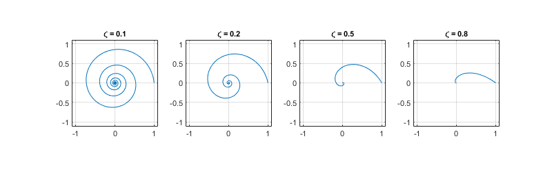

```matlab
%plot -s 800,250

f = 1;
wn = 2*pi*f;
zeta = [0.1 0.2 0.5 0.8];
t = 0:0.01:10;

for i = 1:4
    r = zeta(i)*wn;
    w = wn*sqrt(1-zeta(i)^2);
    z = exp(-1*r*t).*exp(1j*w*t);
    subplot(1,4,i), plot(real(z),imag(z)), grid on
    axis equal, axis([-1.1,1.1 -1.1 1.1])
    title(['\zeta = ',num2str(zeta(i))],'fontsize',8)
end
```

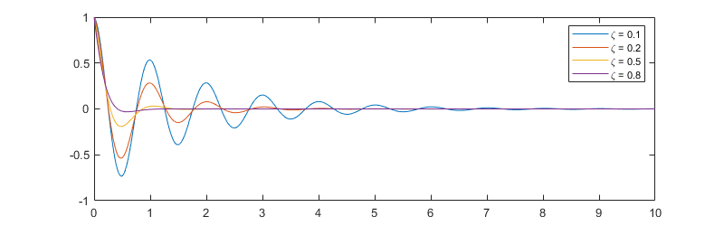

```matlab
for i = 1:4
    r = zeta(i)*wn;
    w = wn*sqrt(1-zeta(i)^2);
    z = exp(-1*r*t).*exp(1j*w*t);
    plot(t,real(z)), hold on
end

hold off
legend(['\zeta = ',num2str(zeta(1))],['\zeta = ',num2str(zeta(2))],...
['\zeta = ',num2str(zeta(3))],['\zeta = ',num2str(zeta(4))])
```

**Example: Door Closers**

In door closers, the mass-spring-damper system ensures that doors close at a controlled speed and do not slam. The spring mechanism provides the necessary force to return the door to its closed position, while the damper controls the speed of this motion.

```matlab
from IPython.display import YouTubeVideo
YouTubeVideo('C2P_5Q8XROk', width = "560", height = "315")
```

[video not shown]

**Example: Torsional Pendulum**

A torsional pendulum is a mechanical system that exhibits angular oscillations about an axis, making it a rotational analog of the linear mass-spring-damper system.

```matlab
from IPython.display import YouTubeVideo
YouTubeVideo('pnhE_-fW0pE', width = "560", height = "315")
```

[video not shown]

**Example: Unicopter**

The Unicopter (a unique single-rotor flying platform) serves as an illustrative example of how mass-spring-damper (MSD) dynamics inform control system design in aerial vehicles. By understanding and applying MSD principles, engineers can enhance the stability and responsiveness of such systems.

```matlab
from IPython.display import YouTubeVideo
YouTubeVideo('N8UX_TDMn-Y', width = "560", height = "315")
```

[video not shown]

```matlab
%%javascript
$.getScript('https://kmahelona.github.io/ipython_notebook_goodies/ipython_notebook_toc.js')
```